# Massachusetts Bay Transportation Authority

The Massachusetts Bay Transportation Authority (“MBTA” or just “the T” for short) manages America’s oldest subway, as well as Greater Boston’s commuter rail, ferry, and bus systems.

We will clean the data. The dataset is stored as an Excel spreadsheet called mbta.xlsx.

The first row is a title, so we’ll need to skip the first row.

```r
# Load readxl
library(readxl)

# Import mbta.xlsx and skip first row: mbta
mbta <- read_excel("mbta.xlsx", skip = 1)
```

```
* `` -> ...1
```

The first step when cleaning a dataset is to explore it a bit. Pay particular attention to how the rows and columns are organized and to the locations of missing values.

```r
# View the structure of mbta
str(mbta)
```

```
Classes ‘tbl_df’, ‘tbl’ and 'data.frame':   11 obs. of  60 variables:
 $ ...1   : num  1 2 3 4 5 6 7 8 9 10 ...
 $ mode   : chr  "All Modes by Qtr" "Boat" "Bus" "Commuter Rail" ...
 $ 2007-01: chr  "NA" "4" "335.819" "142.2" ...
 $ 2007-02: chr  "NA" "3.6" "338.675" "138.5" ...
 $ 2007-03: num  1188 40 340 138 459 ...
 $ 2007-04: chr  "NA" "4.3" "352.162" "139.5" ...
 $ 2007-05: chr  "NA" "4.9" "354.367" "139" ...
 $ 2007-06: num  1246 5.8 350.5 143 477 ...
 $ 2007-07: chr  "NA" "6.521" "357.519" "142.391" ...
 $ 2007-08: chr  "NA" "6.572" "355.479" "142.364" ...
 $ 2007-09: num  1256.57 5.47 372.6 143.05 499.57 ...
 $ 2007-10: chr  "NA" "5.145" "368.847" "146.542" ...
 $ 2007-11: chr  "NA" "3.763" "330.826" "145.089" ...
 $ 2007-12: num  1216.89 2.98 312.92 141.59 448.27 ...
```

[output cut: 46 more lines]

```r
# View the first 6 rows of mbta
head(mbta)
```

| ...1 | mode | 2007-01 | 2007-02 | 2007-03 | 2007-04 | 2007-05 | 2007-06 | 2007-07 | 2007-08 | 2007-09 | 2007-10 | 2007-11 | 2007-12 | 2008-01 | 2008-02 | 2008-03 | 2008-04 | 2008-05 | 2008-06 | 2008-07 | 2008-08 | 2008-09 | 2008-10 | 2008-11 | 2008-12 | 2009-01 | 2009-02 | 2009-03 | 2009-04 | … |
| --- | --- | --- | --- | --- | --- | --- | --- | --- | --- | --- | --- | --- | --- | --- | --- | --- | --- | --- | --- | --- | --- | --- | --- | --- | --- | --- | --- | --- | --- | --- |
| 1 | All Modes by Qtr | NA | NA | 1187.653 | NA | NA | 1245.959 | NA | NA | 1256.571 | NA | NA | 1216.890 | NA | NA | 1253.522 | NA | NA | 1314.821 | NA | NA | 1307.041 | NA | NA | 1232.655 | NA | NA | 1209.792 | NA | … |
| 2 | Boat | 4 | 3.6 | 40.000 | 4.3 | 4.9 | 5.800 | 6.521 | 6.572 | 5.469 | 5.145 | 3.763 | 2.985 | 3.175 | 3.111 | 3.512 | 4.164 | 4.015 | 5.189 | 6.016 | 5.8 | 4.587 | 4.285 | 3.488 | 3.007 | 3.014 | 3.196 | 3.330 | 4.049 | … |
| 3 | Bus | 335.819 | 338.675 | 339.867 | 352.162 | 354.367 | 350.543 | 357.519 | 355.479 | 372.598 | 368.847 | 330.826 | 312.920 | 340.324 | 352.905 | 361.155 | 368.189 | 363.903 | 362.962 | 370.921 | 361.057 | 389.537 | 357.974 | 345.423 | 325.767 | 338.532 | 360.412 | 353.686 | 359.38 | … |
| 4 | Commuter Rail | 142.2 | 138.5 | 137.700 | 139.5 | 139 | 143.000 | 142.391 | 142.364 | 143.051 | 146.542 | 145.089 | 141.585 | 142.145 | 142.607 | 137.453 | 140.389 | 142.585 | 142.057 | 145.731 | 144.565 | 141.907 | 151.957 | 152.952 | 140.810 | 141.448 | 143.529 | 142.893 | 142.34 | … |
| 5 | Heavy Rail | 435.294 | 448.271 | 458.583 | 472.201 | 474.579 | 477.032 | 471.735 | 461.605 | 499.566 | 457.741 | 488.348 | 448.268 | 472.624 | 492.1 | 494.046 | 513.204 | 507.952 | 518.349 | 512.309 | 476.99 | 517.324 | 523.644 | 487.115 | 446.743 | 461.004 | 482.407 | 467.224 | 493.152 | … |
| 6 | Light Rail | 227.231 | 240.262 | 241.444 | 255.557 | 248.262 | 246.108 | 243.286 | 234.907 | 265.748 | 241.434 | 250.497 | 233.379 | 241.223 | 249.306 | 253.132 | 271.07 | 258.351 | 266.961 | 270.158 | 239.344 | 258.171 | 250.063 | 232.068 | 205.420 | 215.66 | 228.737 | 222.844 | 238.232 | … |

```r
# View a summary of mbta
summary(mbta)
```

```
      ...1          mode             2007-01            2007-02             2007-03
 Min.   : 1.0   Length:11          Length:11          Length:11          Min.   :   0.114
 1st Qu.: 3.5   Class :character   Class :character   Class :character   1st Qu.:   9.278
 Median : 6.0   Mode  :character   Mode  :character   Mode  :character   Median : 137.700
 Mean   : 6.0                                                            Mean   : 330.293
 3rd Qu.: 8.5                                                            3rd Qu.: 399.225
 Max.   :11.0                                                            Max.   :1204.725
   2007-04            2007-05             2007-06           2007-07
 Length:11          Length:11          Min.   :   0.096   Length:11
 Class :character   Class :character   1st Qu.:   5.700   Class :character
 Mode  :character   Mode  :character   Median : 143.000   Mode  :character
                                       Mean   : 339.846
                                       3rd Qu.: 413.788
                                       Max.   :1246.129
   2007-08             2007-09           2007-10            2007-11
 Length:11          Min.   :  -0.007   Length:11          Length:11
 Class :character   1st Qu.:   5.539   Class :character   Class :character
 Mode  :character   Median : 143.051   Mode  :character   Mode  :character
                    Mean   : 352.554
                    3rd Qu.: 436.082
                    Max.   :1310.764
    2007-12           2008-01            2008-02             2008-03
 Min.   :  -0.060   Length:11          Length:11          Min.   :   0.058
 1st Qu.:   4.385   Class :character   Class :character   1st Qu.:   5.170
 Median : 141.585   Mode  :character   Mode  :character   Median : 137.453
 Mean   : 321.588                                         Mean   : 345.604
 3rd Qu.: 380.594                                         3rd Qu.: 427.601
 Max.   :1216.890                                         Max.   :1274.031
   2008-04            2008-05             2008-06           2008-07
 Length:11          Length:11          Min.   :   0.060   Length:11
 Class :character   Class :character   1st Qu.:   5.742   Class :character
 Mode  :character   Mode  :character   Median : 142.057   Mode  :character
                                       Mean   : 359.667
                                       3rd Qu.: 440.656
                                       Max.   :1320.728
   2008-08             2008-09           2008-10            2008-11
 Length:11          Min.   :   0.021   Length:11          Length:11
 Class :character   1st Qu.:   5.691   Class :character   Class :character
 Mode  :character   Median : 141.907   Mode  :character   Mode  :character
                    Mean   : 362.099
```

[output cut: 50 more lines]

```
 Max.   :1216.262                                         Max.   :1286.66
   2011-04            2011-05             2011-06           2011-07
 Length:11          Length:11          Min.   :   0.054   Length:11
 Class :character   Class :character   1st Qu.:   6.926   Class :character
 Mode  :character   Mode  :character   Median : 135.581   Mode  :character
                                       Mean   : 353.331
                                       3rd Qu.: 452.923
                                       Max.   :1302.414
   2011-08             2011-09           2011-10
 Length:11          Min.   :   0.043   Length:11
 Class :character   1st Qu.:   6.660   Class :character
 Mode  :character   Median : 136.901   Mode  :character
                    Mean   : 362.555
                    3rd Qu.: 469.204
                    Max.   :1348.754
```

It appears that the data are organized with observations stored as columns rather than as rows.

First, though, we can address the missing data. All of the NA values are stored in the All Modes by Qtr row. This row really belongs in a different data frame; it is a quarterly average of weekday MBTA ridership. Since this dataset tracks monthly average ridership, we’ll remove that row.

Similarly, the 7th row (Pct Chg / Yr) and the 11th row (TOTAL) are not really observations as much as they are analysis. We can remove them as well.

The first column also needs to be removed because it’s just listing the row numbers.

```r
# Remove rows 1, 7, and 11 of mbta: mbta2
mbta2 <- mbta[-c(1, 7, 11),]

# Remove the first column of mbta2: mbta3
mbta3 <- mbta2[,-1]
```

The different modes of transportation (commuter rail, bus, subway, ferry, …) are variables, providing information about each month’s average ridership. The months themselves are observations. You can tell which is which because as you go through time, the month changes, but the modes of transport offered by the T do not.

The first step is to use the gather() function from the tidyr package, which will gather columns into key-value pairs.

```r
# Load tidyr
library(tidyr)
# Gather columns of mbta3: mbta4
mbta4 <- gather(mbta3, month, thou_riders, -mode)

# View the head of mbta4
head(mbta4)
```

| mode | month | thou_riders |
| --- | --- | --- |
| Boat | 2007-01 | 4 |
| Bus | 2007-01 | 335.819 |
| Commuter Rail | 2007-01 | 142.2 |
| Heavy Rail | 2007-01 | 435.294 |
| Light Rail | 2007-01 | 227.231 |
| Private Bus | 2007-01 | 4.772 |

The dataset is long now – notice that the first column still stores variable names, but now, months have their own column instead of being headers. Also notice the data type of each column.

We’ll put variables where they belong (as column names). But first, we can change the average weekday ridership column, thou_riders, into numeric values rather than character strings. That way, you’ll be able to do things like compare values and do math.

```r
# Coerce thou_riders to numeric
mbta4$thou_riders <- as.numeric(mbta4$thou_riders)
```

We can now get variables into columns.

We’ll use the tidyr function spread() to make them into columns containing average weekday ridership for the given month and mode of transport.

```r
# Spread the contents of mbta4: mbta5
mbta5 <- spread(mbta4, mode, thou_riders)

# View the head of mbta5
head(mbta5)
```

| month | Boat | Bus | Commuter Rail | Heavy Rail | Light Rail | Private Bus | RIDE | Trackless Trolley |
| --- | --- | --- | --- | --- | --- | --- | --- | --- |
| 2007-01 | 4.0 | 335.819 | 142.2 | 435.294 | 227.231 | 4.772 | 4.9 | 12.757 |
| 2007-02 | 3.6 | 338.675 | 138.5 | 448.271 | 240.262 | 4.417 | 5.0 | 12.913 |
| 2007-03 | 40.0 | 339.867 | 137.7 | 458.583 | 241.444 | 4.574 | 5.5 | 13.057 |
| 2007-04 | 4.3 | 352.162 | 139.5 | 472.201 | 255.557 | 4.542 | 5.4 | 13.444 |
| 2007-05 | 4.9 | 354.367 | 139.0 | 474.579 | 248.262 | 4.768 | 5.4 | 13.479 |
| 2007-06 | 5.8 | 350.543 | 143.0 | 477.032 | 246.108 | 4.722 | 5.6 | 13.323 |

There’s only one small problem: if you want to look at ridership on the T during every January (for example), the month and year are together in the same column, which makes it a little tricky.

We’ll separate the month column into distinct month and year columns to make life easier.

```r
# Split month column into month and year: mbta6
mbta6 <- separate(mbta5, month, c("year", "month"), sep = "-")

# View the head of mbta6
head(mbta6)
```

| year | month | Boat | Bus | Commuter Rail | Heavy Rail | Light Rail | Private Bus | RIDE | Trackless Trolley |
| --- | --- | --- | --- | --- | --- | --- | --- | --- | --- |
| 2007 | 01 | 4.0 | 335.819 | 142.2 | 435.294 | 227.231 | 4.772 | 4.9 | 12.757 |
| 2007 | 02 | 3.6 | 338.675 | 138.5 | 448.271 | 240.262 | 4.417 | 5.0 | 12.913 |
| 2007 | 03 | 40.0 | 339.867 | 137.7 | 458.583 | 241.444 | 4.574 | 5.5 | 13.057 |
| 2007 | 04 | 4.3 | 352.162 | 139.5 | 472.201 | 255.557 | 4.542 | 5.4 | 13.444 |
| 2007 | 05 | 4.9 | 354.367 | 139.0 | 474.579 | 248.262 | 4.768 | 5.4 | 13.479 |
| 2007 | 06 | 5.8 | 350.543 | 143.0 | 477.032 | 246.108 | 4.722 | 5.6 | 13.323 |

It’s a good idea to screen the data for any obvious mistakes and/or outliers.

We can plot a histogram.

```r
# View a summary of mbta6
summary(mbta6)
```

```
     year              month                Boat             Bus        Commuter Rail
 Length:58          Length:58          Min.   : 2.985   Min.   :312.9   Min.   :121.4
 Class :character   Class :character   1st Qu.: 3.494   1st Qu.:345.6   1st Qu.:131.4
 Mode  :character   Mode  :character   Median : 4.293   Median :359.9   Median :138.8
                                       Mean   : 5.068   Mean   :358.6   Mean   :137.4
                                       3rd Qu.: 5.356   3rd Qu.:372.2   3rd Qu.:142.4
                                       Max.   :40.000   Max.   :398.5   Max.   :153.0
   Heavy Rail      Light Rail     Private Bus         RIDE       Trackless Trolley
 Min.   :435.3   Min.   :194.4   Min.   :2.213   Min.   :4.900   Min.   : 5.777
 1st Qu.:471.1   1st Qu.:220.6   1st Qu.:2.641   1st Qu.:5.965   1st Qu.:11.679
 Median :487.3   Median :231.9   Median :2.820   Median :6.615   Median :12.598
 Mean   :489.3   Mean   :233.0   Mean   :3.352   Mean   :6.604   Mean   :12.125
 3rd Qu.:511.3   3rd Qu.:244.5   3rd Qu.:4.167   3rd Qu.:7.149   3rd Qu.:13.320
 Max.   :554.9   Max.   :271.1   Max.   :4.878   Max.   :8.598   Max.   :15.109
```

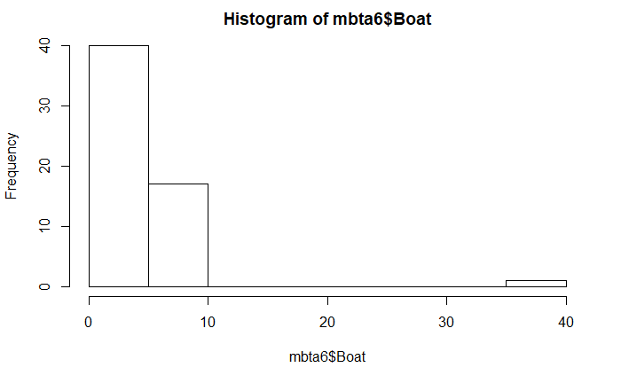

```r
# Generate a histogram of Boat column
hist(mbta6$Boat)
```

That’s quite an interesting histogram – every value clustered around 4 and one loner out around 40.

Think for a minute about that Boat histogram. Every month, average weekday commuter boat ridership was on either side of four thousand. Then, one month it jumped to 40 thousand without warning?

Unless the Olympics were happening in Boston that month (they weren’t), this value is certainly an error. We can assume that whoever was entering the data that month accidentally typed 40 instead of 4.

Because it’s an error, we don’t want this value influencing your analysis.

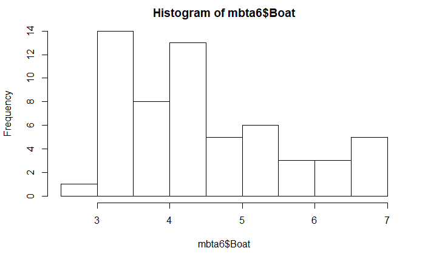

```r
# Find the row number of the incorrect value: i
i <- which(mbta6$Boat>30)

# Replace the incorrect value with 4
mbta6$Boat[i] <- 4

# Generate a histogram of Boat column
hist(mbta6$Boat)
```